# act_report

## Report: act_report

Visualization is a great way to communicate insights to the target audience. As popularity said, a picture is worth a thousand word. From the WeRateDogs tweets, the following insights were obtained in my analysis;

### What is the most popular source of tweets

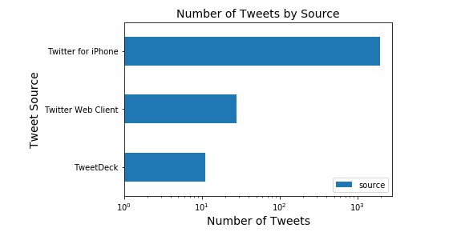

- From the datasets, the largest chunck of tweet sources came from iphone users. These set of users make up a massive 98% of the grand total tweet

### What is the relationship between retweets and favorite counts

- Does the count of likes on a dog means there will be as much retweets on the same image? Majority of the time, it is observed that there is a strong positive relationshiop between the count of liked tweet and a corresponding retweet of the same image. This implies that, when a user likes a dog tweet, they are very much likely to retweet it on their own account.

[figure not shown]

### What dog name is most common among all the dogs

- From the datasets in the `twitter_archive_df`, many dogs have no names, however from the many chunck of the names that were provided, many dog owners decided the name their dogs *Charlie*. 11 of the dogs were named Charlie, recording the highest unique name given to dogs in the dataset.

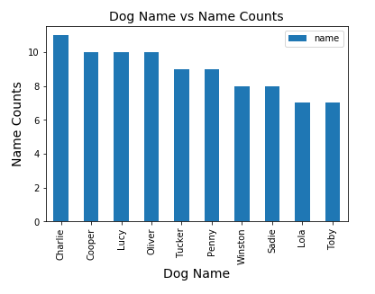

### Top 5 Breeds of Dogs

- There are many dog breeds on WeRateDogs archive. After cleaning the 3 datasets, the `twitter_archive_master` dataset, the **Bouvier_des_Flandres** got the highest average rating of **1.3**.

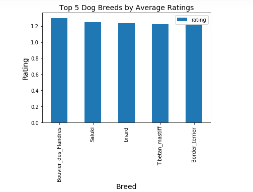

### Other Insights that were obtained are;

1. There were many dogs with the highest rating of 1.4. Most of them have no name, however, among those that have names, **Bo** is the most liked dog
1. Of the dog breeds whose records were provided, the **French_bulldog** is the most liked breed with 3% of the total liked tweets.